# Risk Factor Analysis

## Outcome Variable

**Outcome Variable:** ever_stunted

## Predictor Variables

**Intervention Variable:** enstunt

**Adjustment Set:**

unadjusted

## Stratifying Variables

The analysis was stratified on these variable(s):

- agecat
- studyid

The following strata were considered:

- agecat: 12 months, studyid: ki0047075b-MAL-ED
- agecat: 12 months, studyid: ki1000108-CMC-V-BCS-2002
- agecat: 12 months, studyid: ki1000108-IRC
- agecat: 12 months, studyid: ki1000109-EE
- agecat: 12 months, studyid: ki1000109-ResPak
- agecat: 12 months, studyid: ki1000304b-SAS-FoodSuppl
- agecat: 12 months, studyid: ki1017093-NIH-Birth
- agecat: 12 months, studyid: ki1017093c-NIH-Crypto
- agecat: 12 months, studyid: ki1066203-TanzaniaChild2
- agecat: 12 months, studyid: ki1101329-Keneba
- agecat: 12 months, studyid: ki1112895-Guatemala BSC
- agecat: 12 months, studyid: ki1113344-GMS-Nepal
- agecat: 12 months, studyid: ki1114097-CMIN
- agecat: 12 months, studyid: ki1114097-CONTENT
- agecat: 12 months, studyid: ki1126311-ZVITAMBO
- agecat: 12 months, studyid: ki1135781-COHORTS
- agecat: 12 months, studyid: ki1148112-LCNI-5
- agecat: 18 months, studyid: ki0047075b-MAL-ED
- agecat: 18 months, studyid: ki1000108-CMC-V-BCS-2002
- agecat: 18 months, studyid: ki1000108-IRC
- agecat: 18 months, studyid: ki1000109-EE
- agecat: 18 months, studyid: ki1000109-ResPak
- agecat: 18 months, studyid: ki1000304b-SAS-FoodSuppl
- agecat: 18 months, studyid: ki1017093-NIH-Birth
- agecat: 18 months, studyid: ki1017093c-NIH-Crypto
- agecat: 18 months, studyid: ki1066203-TanzaniaChild2
- agecat: 18 months, studyid: ki1101329-Keneba
- agecat: 18 months, studyid: ki1112895-Guatemala BSC
- agecat: 18 months, studyid: ki1113344-GMS-Nepal
- agecat: 18 months, studyid: ki1114097-CMIN
- agecat: 18 months, studyid: ki1114097-CONTENT
- agecat: 18 months, studyid: ki1126311-ZVITAMBO
- agecat: 18 months, studyid: ki1135781-COHORTS
- agecat: 18 months, studyid: ki1148112-LCNI-5
- agecat: 24 months, studyid: ki0047075b-MAL-ED
- agecat: 24 months, studyid: ki1000108-CMC-V-BCS-2002
- agecat: 24 months, studyid: ki1000108-IRC
- agecat: 24 months, studyid: ki1000109-EE
- agecat: 24 months, studyid: ki1000304b-SAS-FoodSuppl
- agecat: 24 months, studyid: ki1017093-NIH-Birth
- agecat: 24 months, studyid: ki1017093c-NIH-Crypto
- agecat: 24 months, studyid: ki1066203-TanzaniaChild2
- agecat: 24 months, studyid: ki1101329-Keneba
- agecat: 24 months, studyid: ki1113344-GMS-Nepal
- agecat: 24 months, studyid: ki1114097-CMIN
- agecat: 24 months, studyid: ki1114097-CONTENT
- agecat: 24 months, studyid: ki1126311-ZVITAMBO
- agecat: 24 months, studyid: ki1135781-COHORTS
- agecat: 24 months, studyid: ki1148112-LCNI-5
- agecat: 3 months, studyid: ki0047075b-MAL-ED
- agecat: 3 months, studyid: ki1000108-CMC-V-BCS-2002
- agecat: 3 months, studyid: ki1000108-IRC
- agecat: 3 months, studyid: ki1000109-EE
- agecat: 3 months, studyid: ki1000109-ResPak
- agecat: 3 months, studyid: ki1017093-NIH-Birth
- agecat: 3 months, studyid: ki1017093c-NIH-Crypto
- agecat: 3 months, studyid: ki1066203-TanzaniaChild2
- agecat: 3 months, studyid: ki1101329-Keneba
- agecat: 3 months, studyid: ki1113344-GMS-Nepal
- agecat: 3 months, studyid: ki1114097-CMIN
- agecat: 3 months, studyid: ki1114097-CONTENT
- agecat: 3 months, studyid: ki1126311-ZVITAMBO
- agecat: 3 months, studyid: ki1135781-COHORTS
- agecat: 6 months, studyid: ki0047075b-MAL-ED
- agecat: 6 months, studyid: ki1000108-CMC-V-BCS-2002
- agecat: 6 months, studyid: ki1000108-IRC
- agecat: 6 months, studyid: ki1000109-EE
- agecat: 6 months, studyid: ki1000109-ResPak
- agecat: 6 months, studyid: ki1000304b-SAS-FoodSuppl
- agecat: 6 months, studyid: ki1017093-NIH-Birth
- agecat: 6 months, studyid: ki1017093c-NIH-Crypto
- agecat: 6 months, studyid: ki1066203-TanzaniaChild2
- agecat: 6 months, studyid: ki1101329-Keneba
- agecat: 6 months, studyid: ki1112895-Guatemala BSC
- agecat: 6 months, studyid: ki1113344-GMS-Nepal
- agecat: 6 months, studyid: ki1114097-CMIN
- agecat: 6 months, studyid: ki1114097-CONTENT
- agecat: 6 months, studyid: ki1126311-ZVITAMBO
- agecat: 6 months, studyid: ki1135781-COHORTS
- agecat: 6 months, studyid: ki1148112-LCNI-5

### Dropped Strata

Some strata were dropped due to rare outcomes:

- agecat: 3 months, studyid: ki0047075b-MAL-ED
- agecat: 3 months, studyid: ki1000108-CMC-V-BCS-2002
- agecat: 3 months, studyid: ki1000108-IRC
- agecat: 3 months, studyid: ki1000109-EE
- agecat: 3 months, studyid: ki1000109-ResPak
- agecat: 3 months, studyid: ki1017093-NIH-Birth
- agecat: 3 months, studyid: ki1017093c-NIH-Crypto
- agecat: 3 months, studyid: ki1066203-TanzaniaChild2
- agecat: 3 months, studyid: ki1113344-GMS-Nepal
- agecat: 3 months, studyid: ki1114097-CMIN
- agecat: 3 months, studyid: ki1114097-CONTENT
- agecat: 3 months, studyid: ki1135781-COHORTS
- agecat: 6 months, studyid: ki0047075b-MAL-ED
- agecat: 6 months, studyid: ki1000108-CMC-V-BCS-2002
- agecat: 6 months, studyid: ki1000108-IRC
- agecat: 6 months, studyid: ki1000109-EE
- agecat: 6 months, studyid: ki1000109-ResPak
- agecat: 6 months, studyid: ki1000304b-SAS-FoodSuppl
- agecat: 6 months, studyid: ki1017093-NIH-Birth
- agecat: 6 months, studyid: ki1017093c-NIH-Crypto
- agecat: 6 months, studyid: ki1066203-TanzaniaChild2
- agecat: 6 months, studyid: ki1112895-Guatemala BSC
- agecat: 6 months, studyid: ki1113344-GMS-Nepal
- agecat: 6 months, studyid: ki1114097-CMIN
- agecat: 6 months, studyid: ki1114097-CONTENT
- agecat: 6 months, studyid: ki1135781-COHORTS
- agecat: 6 months, studyid: ki1148112-LCNI-5
- agecat: 12 months, studyid: ki0047075b-MAL-ED
- agecat: 12 months, studyid: ki1000108-CMC-V-BCS-2002
- agecat: 12 months, studyid: ki1000108-IRC
- agecat: 12 months, studyid: ki1000109-EE
- agecat: 12 months, studyid: ki1000109-ResPak
- agecat: 12 months, studyid: ki1000304b-SAS-FoodSuppl
- agecat: 12 months, studyid: ki1017093-NIH-Birth
- agecat: 12 months, studyid: ki1017093c-NIH-Crypto
- agecat: 12 months, studyid: ki1066203-TanzaniaChild2
- agecat: 12 months, studyid: ki1112895-Guatemala BSC
- agecat: 12 months, studyid: ki1113344-GMS-Nepal
- agecat: 12 months, studyid: ki1114097-CMIN
- agecat: 12 months, studyid: ki1114097-CONTENT
- agecat: 12 months, studyid: ki1135781-COHORTS
- agecat: 12 months, studyid: ki1148112-LCNI-5
- agecat: 18 months, studyid: ki0047075b-MAL-ED
- agecat: 18 months, studyid: ki1000108-CMC-V-BCS-2002
- agecat: 18 months, studyid: ki1000108-IRC
- agecat: 18 months, studyid: ki1000109-EE
- agecat: 18 months, studyid: ki1000109-ResPak
- agecat: 18 months, studyid: ki1000304b-SAS-FoodSuppl
- agecat: 18 months, studyid: ki1017093-NIH-Birth
- agecat: 18 months, studyid: ki1017093c-NIH-Crypto
- agecat: 18 months, studyid: ki1066203-TanzaniaChild2
- agecat: 18 months, studyid: ki1112895-Guatemala BSC
- agecat: 18 months, studyid: ki1113344-GMS-Nepal
- agecat: 18 months, studyid: ki1114097-CMIN
- agecat: 18 months, studyid: ki1114097-CONTENT
- agecat: 18 months, studyid: ki1135781-COHORTS
- agecat: 18 months, studyid: ki1148112-LCNI-5
- agecat: 24 months, studyid: ki0047075b-MAL-ED
- agecat: 24 months, studyid: ki1000108-CMC-V-BCS-2002
- agecat: 24 months, studyid: ki1000108-IRC
- agecat: 24 months, studyid: ki1000109-EE
- agecat: 24 months, studyid: ki1000304b-SAS-FoodSuppl
- agecat: 24 months, studyid: ki1017093-NIH-Birth
- agecat: 24 months, studyid: ki1017093c-NIH-Crypto
- agecat: 24 months, studyid: ki1066203-TanzaniaChild2
- agecat: 24 months, studyid: ki1113344-GMS-Nepal
- agecat: 24 months, studyid: ki1114097-CMIN
- agecat: 24 months, studyid: ki1114097-CONTENT
- agecat: 24 months, studyid: ki1126311-ZVITAMBO
- agecat: 24 months, studyid: ki1135781-COHORTS
- agecat: 24 months, studyid: ki1148112-LCNI-5

## Methods Detail

We’re interested in the causal parameters $E[Y_a]$ for all values of $a \in \mathcal{A}$. These parameters represent the mean outcome if, possibly contrary to fact, we intervened to set all units to have $A=a$. Under the randomization and positivity assumptions, these are identified by the statistical parameters $\psi_a=E_W[E_{Y|A,W}(Y|A=a,W)]$. In addition, we’re interested in the mean of $Y$, $E[Y]$ under no intervention (the observed mean). We will estimate these parameters by using SuperLearner to fit the relevant likelihood factors – $E_{Y|A,W}(Y|A=a,W)$ and $p(A=a|W)$, and then updating our likelihood fit using a joint TMLE.

For unadjusted analyses ($W=\{\}$), initial likelihoods were estimated using Lrnr_glm to estimate the simple $E(Y|A)$ and Lrnr_mean to estimate $p(A)$. For adjusted analyses, a small library containing Lrnr_glmnet, Lrnr_xgboost, and Lrnr_mean was used.

Having estimated these parameters, we will then use the delta method to estimate relative risks and attributable risks relative to a prespecified baseline level of $A$.

# Results Detail

## Results Plots

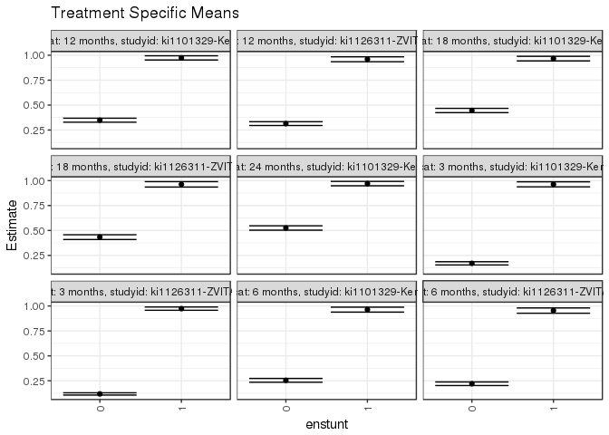

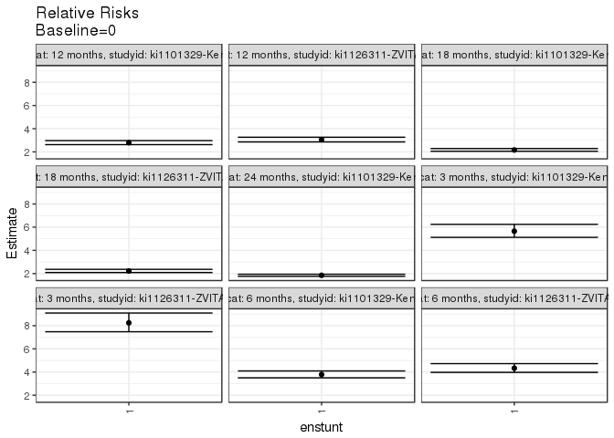

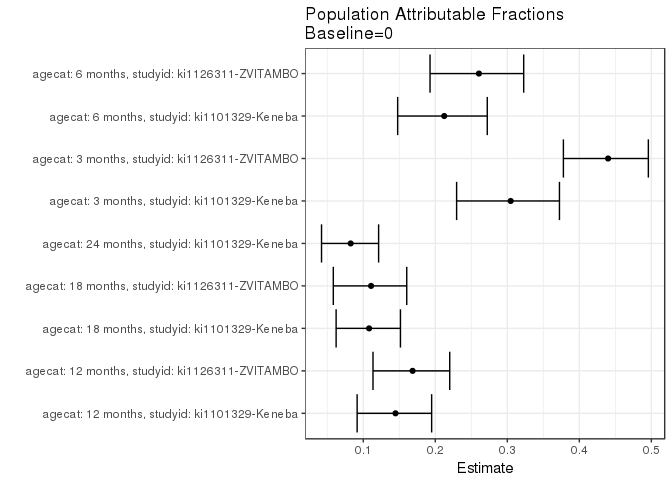

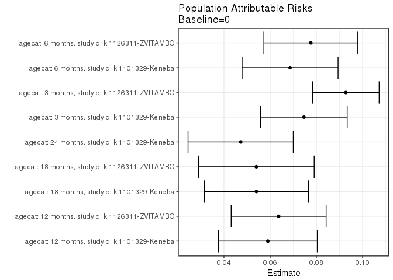

## Data Summary

| agecat | studyid | A | n | nA | nAY0 | nAY1 |
| --- | --- | --- | --- | --- | --- | --- |
| 3 months | ki0047075b-MAL-ED | 0 | 1499 | 1300 | 1112 | 188 |
| 3 months | ki0047075b-MAL-ED | 1 | 1499 | 199 | 0 | 199 |
| 3 months | ki1000108-CMC-V-BCS-2002 | 0 | 97 | 81 | 56 | 25 |
| 3 months | ki1000108-CMC-V-BCS-2002 | 1 | 97 | 16 | 0 | 16 |
| 3 months | ki1000108-IRC | 0 | 410 | 362 | 278 | 84 |
| 3 months | ki1000108-IRC | 1 | 410 | 48 | 2 | 46 |
| 3 months | ki1000109-EE | 0 | 9 | 6 | 4 | 2 |
| 3 months | ki1000109-EE | 1 | 9 | 3 | 0 | 3 |
| 3 months | ki1000109-ResPak | 0 | 91 | 70 | 40 | 30 |
| 3 months | ki1000109-ResPak | 1 | 91 | 21 | 0 | 21 |
| 3 months | ki1000304b-SAS-FoodSuppl | 0 | 0 | 0 | 0 | 0 |
| 3 months | ki1000304b-SAS-FoodSuppl | 1 | 0 | 0 | 0 | 0 |
| 3 months | ki1017093-NIH-Birth | 0 | 624 | 525 | 484 | 41 |
| 3 months | ki1017093-NIH-Birth | 1 | 624 | 99 | 0 | 99 |
| 3 months | ki1017093c-NIH-Crypto | 0 | 27 | 22 | 21 | 1 |
| 3 months | ki1017093c-NIH-Crypto | 1 | 27 | 5 | 0 | 5 |
| 3 months | ki1066203-TanzaniaChild2 | 0 | 5 | 5 | 4 | 1 |
| 3 months | ki1066203-TanzaniaChild2 | 1 | 5 | 0 | 0 | 0 |
| 3 months | ki1101329-Keneba | 0 | 2295 | 2079 | 1725 | 354 |
| 3 months | ki1101329-Keneba | 1 | 2295 | 216 | 8 | 208 |
| 3 months | ki1112895-Guatemala BSC | 0 | 0 | 0 | 0 | 0 |
| 3 months | ki1112895-Guatemala BSC | 1 | 0 | 0 | 0 | 0 |
| 3 months | ki1113344-GMS-Nepal | 0 | 53 | 43 | 41 | 2 |
| 3 months | ki1113344-GMS-Nepal | 1 | 53 | 10 | 0 | 10 |
| 3 months | ki1114097-CMIN | 0 | 387 | 347 | 338 | 9 |
| 3 months | ki1114097-CMIN | 1 | 387 | 40 | 0 | 40 |
| 3 months | ki1114097-CONTENT | 0 | 55 | 49 | 45 | 4 |
| 3 months | ki1114097-CONTENT | 1 | 55 | 6 | 0 | 6 |
| 3 months | ki1126311-ZVITAMBO | 0 | 3467 | 3091 | 2726 | 365 |
| 3 months | ki1126311-ZVITAMBO | 1 | 3467 | 376 | 10 | 366 |

[output cut: 140 more lines]

## Results Table

### Parameter: TSM

| agecat | studyid | intervention_level | baseline_level | estimate | ci_lower | ci_upper |
| --- | --- | --- | --- | --- | --- | --- |
| 3 months | ki1101329-Keneba | 0 | NA | 0.1702742 | 0.1541136 | 0.1864348 |
| 3 months | ki1101329-Keneba | 1 | NA | 0.9629629 | 0.9377723 | 0.9881536 |
| 3 months | ki1126311-ZVITAMBO | 0 | NA | 0.1180848 | 0.1067066 | 0.1294629 |
| 3 months | ki1126311-ZVITAMBO | 1 | NA | 0.9734043 | 0.9571387 | 0.9896698 |
| 6 months | ki1101329-Keneba | 0 | NA | 0.2544031 | 0.2355181 | 0.2732881 |
| 6 months | ki1101329-Keneba | 1 | NA | 0.9634703 | 0.9386181 | 0.9883225 |
| 6 months | ki1126311-ZVITAMBO | 0 | NA | 0.2201880 | 0.2021182 | 0.2382578 |
| 6 months | ki1126311-ZVITAMBO | 1 | NA | 0.9539749 | 0.9274037 | 0.9805461 |
| 12 months | ki1101329-Keneba | 0 | NA | 0.3484708 | 0.3283630 | 0.3685786 |
| 12 months | ki1101329-Keneba | 1 | NA | 0.9733333 | 0.9522780 | 0.9943887 |
| 12 months | ki1126311-ZVITAMBO | 0 | NA | 0.3142101 | 0.2950935 | 0.3333266 |
| 12 months | ki1126311-ZVITAMBO | 1 | NA | 0.9596774 | 0.9351899 | 0.9841650 |
| 18 months | ki1101329-Keneba | 0 | NA | 0.4457478 | 0.4242057 | 0.4672899 |
| 18 months | ki1101329-Keneba | 1 | NA | 0.9662447 | 0.9432470 | 0.9892423 |
| 18 months | ki1126311-ZVITAMBO | 0 | NA | 0.4331713 | 0.4092267 | 0.4571159 |
| 18 months | ki1126311-ZVITAMBO | 1 | NA | 0.9625668 | 0.9353530 | 0.9897806 |
| 24 months | ki1101329-Keneba | 0 | NA | 0.5248479 | 0.5028021 | 0.5468937 |
| 24 months | ki1101329-Keneba | 1 | NA | 0.9700855 | 0.9482539 | 0.9919170 |

### Parameter: E(Y)

| agecat | studyid | intervention_level | baseline_level | estimate | ci_lower | ci_upper |
| --- | --- | --- | --- | --- | --- | --- |
| 3 months | ki1101329-Keneba | NA | NA | 0.2448802 | 0.2354085 | 0.2543518 |
| 3 months | ki1126311-ZVITAMBO | NA | NA | 0.2108451 | 0.2019909 | 0.2196994 |
| 6 months | ki1101329-Keneba | NA | NA | 0.3230225 | 0.3143835 | 0.3316616 |
| 6 months | ki1126311-ZVITAMBO | NA | NA | 0.2977876 | 0.2884822 | 0.3070930 |
| 12 months | ki1101329-Keneba | NA | NA | 0.4074696 | 0.4001320 | 0.4148072 |
| 12 months | ki1126311-ZVITAMBO | NA | NA | 0.3778838 | 0.3703587 | 0.3854090 |
| 18 months | ki1101329-Keneba | NA | NA | 0.4997810 | 0.4932673 | 0.5062947 |
| 18 months | ki1126311-ZVITAMBO | NA | NA | 0.4871795 | 0.4798421 | 0.4945168 |
| 24 months | ki1101329-Keneba | NA | NA | 0.5720762 | 0.5663536 | 0.5777987 |

### Parameter: RR

| agecat | studyid | intervention_level | baseline_level | estimate | ci_lower | ci_upper |
| --- | --- | --- | --- | --- | --- | --- |
| 3 months | ki1101329-Keneba | 1 | 0 | 5.655367 | 5.125134 | 6.240457 |
| 3 months | ki1126311-ZVITAMBO | 1 | 0 | 8.243267 | 7.475289 | 9.090144 |
| 6 months | ki1101329-Keneba | 1 | 0 | 3.787179 | 3.500953 | 4.096807 |
| 6 months | ki1126311-ZVITAMBO | 1 | 0 | 4.332547 | 3.972884 | 4.724769 |
| 12 months | ki1101329-Keneba | 1 | 0 | 2.793156 | 2.626226 | 2.970697 |
| 12 months | ki1126311-ZVITAMBO | 1 | 0 | 3.054254 | 2.859255 | 3.262552 |
| 18 months | ki1101329-Keneba | 1 | 0 | 2.167694 | 2.054007 | 2.287672 |
| 18 months | ki1126311-ZVITAMBO | 1 | 0 | 2.222139 | 2.088367 | 2.364480 |
| 24 months | ki1101329-Keneba | 1 | 0 | 1.848317 | 1.762305 | 1.938528 |

### Parameter: PAR

| agecat | studyid | intervention_level | baseline_level | estimate | ci_lower | ci_upper |
| --- | --- | --- | --- | --- | --- | --- |
| 3 months | ki1101329-Keneba | 0 | NA | 0.0746060 | 0.0558743 | 0.0933377 |
| 3 months | ki1126311-ZVITAMBO | 0 | NA | 0.0927603 | 0.0783430 | 0.1071777 |
| 6 months | ki1101329-Keneba | 0 | NA | 0.0686194 | 0.0478522 | 0.0893866 |
| 6 months | ki1126311-ZVITAMBO | 0 | NA | 0.0775996 | 0.0572746 | 0.0979246 |
| 12 months | ki1101329-Keneba | 0 | NA | 0.0589988 | 0.0375940 | 0.0804035 |
| 12 months | ki1126311-ZVITAMBO | 0 | NA | 0.0636738 | 0.0431294 | 0.0842182 |
| 18 months | ki1101329-Keneba | 0 | NA | 0.0540332 | 0.0315278 | 0.0765386 |
| 18 months | ki1126311-ZVITAMBO | 0 | NA | 0.0540082 | 0.0289646 | 0.0790517 |
| 24 months | ki1101329-Keneba | 0 | NA | 0.0472283 | 0.0244519 | 0.0700047 |

### Parameter: PAF

| agecat | studyid | intervention_level | baseline_level | estimate | ci_lower | ci_upper |
| --- | --- | --- | --- | --- | --- | --- |
| 3 months | ki1101329-Keneba | 0 | NA | 0.3046633 | 0.2296197 | 0.3723968 |
| 3 months | ki1126311-ZVITAMBO | 0 | NA | 0.4399455 | 0.3778736 | 0.4958242 |
| 6 months | ki1101329-Keneba | 0 | NA | 0.2124292 | 0.1477698 | 0.2721828 |
| 6 months | ki1126311-ZVITAMBO | 0 | NA | 0.2605870 | 0.1927206 | 0.3227480 |
| 12 months | ki1101329-Keneba | 0 | NA | 0.1447931 | 0.0915036 | 0.1949568 |
| 12 months | ki1126311-ZVITAMBO | 0 | NA | 0.1685010 | 0.1135307 | 0.2200624 |
| 18 months | ki1101329-Keneba | 0 | NA | 0.1081137 | 0.0623345 | 0.1516579 |
| 18 months | ki1126311-ZVITAMBO | 0 | NA | 0.1108589 | 0.0584303 | 0.1603681 |
| 24 months | ki1101329-Keneba | 0 | NA | 0.0825559 | 0.0420740 | 0.1213271 |